# COMPSCIX 415.2 Homework 4

# Section 5.6.7: 5).Which carrier has the worst delays? Challenge: can you disentangle the effects of bad airports vs. bad carriers? Why/why not? (Hint: think about flights %>% group_by(carrier, dest) %>% summarise(n()))

```r
#carriers with worst delays
carriers_worst_delay_carrier <- flights %>%
                              group_by(carrier) %>%
                              summarize(count = n(),
                                    average_delay = mean(dep_delay, na.rm = TRUE)
                                 # delay = mean(arr_delay, na.rm = TRUE),
                                #  proportion_delay = delay/count
                                  ) %>%
                              arrange(desc(average_delay))
carriers_worst_delay_carrier
```

```
## # A tibble: 16 x 3
##    carrier count average_delay
##      <chr> <int>         <dbl>
##  1      F9   685     20.215543
##  2      EV 54173     19.955390
##  3      YV   601     18.996330
##  4      FL  3260     18.726075
##  5      WN 12275     17.711744
##  6      9E 18460     16.725769
##  7      B6 54635     13.022522
##  8      VX  5162     12.869421
##  9      OO    32     12.586207
## 10      UA 58665     12.106073
## 11      MQ 26397     10.552041
## 12      DL 48110      9.264505
## 13      AA 32729      8.586016
## 14      AS   714      5.804775
## 15      HA   342      4.900585
## 16      US 20536      3.782418
```

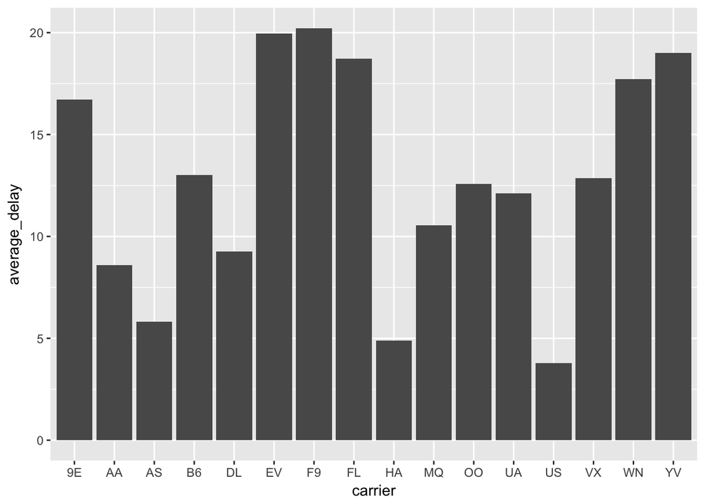

```r
 ggplot(data = carriers_worst_delay_carrier, mapping = aes(x = carrier, y = average_delay)) +
  geom_col()
```

```r
#average delay time isn’t helpful, and the average delay time reveals F9 to be the worst, but I’m suspicious of outliers.Let’s look at the number of delayed (arrivals OR departure) flights that were delayed for more than 10 minutes. We see below that ExpressJet Airlines has the most delays by pure volume. We could also look at proportions, but you get the idea.

flights %>% filter(dep_delay > 10 | arr_delay > 10) %>%
  count(carrier, sort = TRUE) %>%
  head(10)
```

```
## # A tibble: 10 x 2
##    carrier     n
##      <chr> <int>
##  1      EV 20689
##  2      UA 19655
##  3      B6 19255
##  4      DL 13195
##  5      MQ  8891
##  6      AA  8668
##  7      9E  6079
##  8      US  4940
##  9      WN  4662
## 10      VX  1499
```

```r
#just considering flights with departure delay > 10 mins
flights %>% filter(dep_delay > 10 | arr_delay > 10) %>%
            group_by(carrier) %>%
            arrange(carrier) %>%
            # count()
           # count(carrier, sort = TRUE)
            #remember that sum works on numeric columns only, it adds up the values in that column. if you want to know the count of, for example here, the total count of each type of carriers , use count_carrer = n() function.
  #Also remember that arrange() can be applied after group_by, also can be applid after summarizing values in a group , like below. Arrange() needs to be preceeeded by %>%
            summarise(
              count_carrier = n()
              ) %>%
            arrange(desc(count_carrier))
```

```
## # A tibble: 16 x 2
##    carrier count_carrier
##      <chr>         <int>
##  1      EV         20689
##  2      UA         19655
##  3      B6         19255
##  4      DL         13195
##  5      MQ          8891
##  6      AA          8668
##  7      9E          6079
##  8      US          4940
##  9      WN          4662
## 10      VX          1499
## 11      FL          1429
## 12      F9           348
## 13      YV           224
## 14      AS           170
## 15      HA            71
## 16      OO             7
```

```r
#There may also be airports that are generally “bad” airports to fly into, which will cause both arrival and departure delays to and from that airport. Again, let’s simply look at volume of delays (we’ll just look at arrival delays and destination airports) where the delay was more than 10 minutes.

#Let’s focus on our worst carriers: EV; UA; and B6. Here, we take our three worst carriers in terms of volume of delayed flights, and then plot the proportion of delayed flights for each destination. If the delays are concentrated at a few airports, this may say something more about the airport than the carrier.

flights_EVUAB6_delayedgt10 <- flights %>%
                              filter(carrier %in% c('EV', 'UA', 'B6')) %>%
                              mutate(delayed = arr_delay > 10) %>%
                              group_by(dest, carrier) %>%
                              arrange(dest, carrier)
flights_EVUAB6_delayedgt10
```

```
## # A tibble: 167,473 x 21
## # Groups:   dest, carrier [150]
##     year month   day dep_time sched_dep_time dep_delay arr_time
##    <int> <int> <int>    <int>          <int>     <dbl>    <int>
##  1  2013    10     1     1955           2001        -6     2213
##  2  2013    10     2     2010           2001         9     2230
##  3  2013    10     3     1955           2001        -6     2232
##  4  2013    10     4     2017           2001        16     2304
##  5  2013    10     5     1959           1959         0     2226
##  6  2013    10     6     1959           2001        -2     2234
##  7  2013    10     7     2002           2001         1     2233
##  8  2013    10     8     1957           2001        -4     2216
##  9  2013    10     9     1957           2001        -4     2220
## 10  2013    10    10     2011           2001        10     2235
## # ... with 167,463 more rows, and 14 more variables: sched_arr_time <int>,
## #   arr_delay <dbl>, carrier <chr>, flight <int>, tailnum <chr>,
## #   origin <chr>, dest <chr>, air_time <dbl>, distance <dbl>, hour <dbl>,
## #   minute <dbl>, time_hour <dttm>, cancelled <lgl>, delayed <lgl>
```

```r
#Very important revelation. Sum() under Summarise() works on columns with boolean values (true or false), like below example, it works on delayed column. But sum() doesnt work on columns with charater values, for example it cannot find the count of grouped carrier, summarise (sum(carrier)), summarise(sum(dest)) does not work. we have to use summarise(n()) function for that. Mean() also works on boolean and numeric columns, thus prop_delay = mean(delayed, na.rm = TRUE) works in below example

  flights_delay_analysis <- flights_EVUAB6_delayedgt10 %>%
                                summarise(
                                prop_delay = mean(delayed, na.rm = TRUE)
                                )
                                #sum_delay = sum(delayed, na.rm = TRUE),
                                #sum_cancelled = sum(cancelled, na.rm = TRUE),
                                #sum(air_time, na.rm = TRUE)
  flights_delay_analysis
```

```
## # A tibble: 150 x 3
## # Groups:   dest [?]
##     dest carrier prop_delay
##    <chr>   <chr>      <dbl>
##  1   ABQ      B6  0.3385827
##  2   ACK      B6  0.2462121
##  3   ALB      EV  0.3325359
##  4   ANC      UA  0.1250000
##  5   ATL      EV  0.4094203
##  6   ATL      UA  0.2843137
##  7   AUS      B6  0.3665768
##  8   AUS      UA  0.2620482
##  9   AVL      EV  0.2629482
## 10   BDL      EV  0.2617284
## # ... with 140 more rows
```

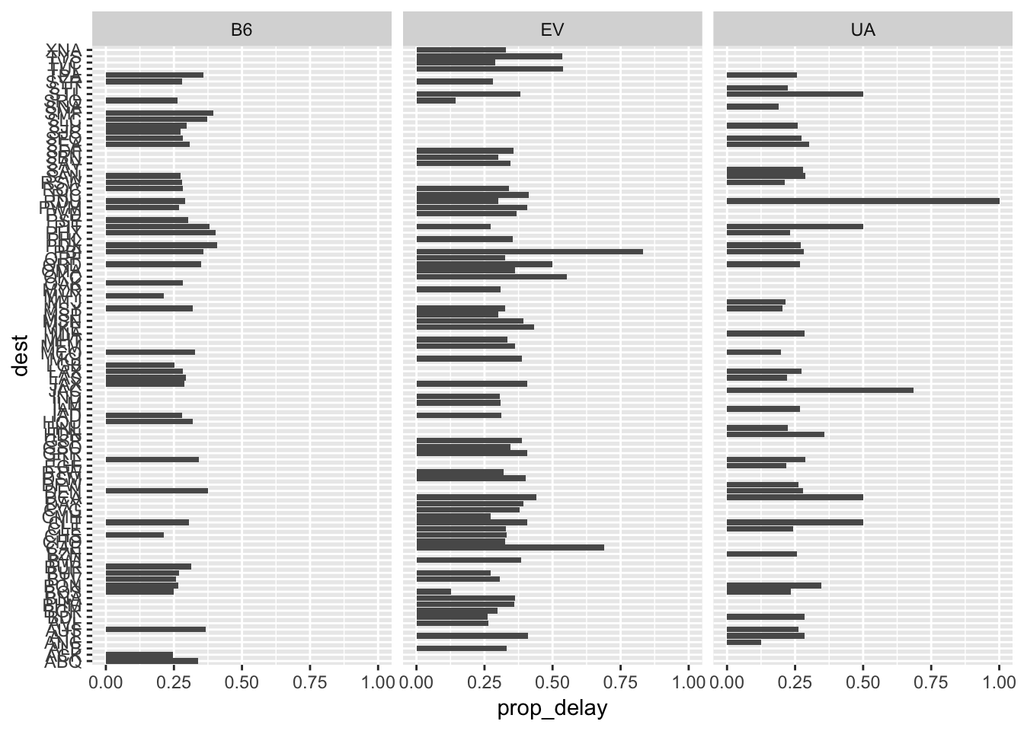

```r
  ggplot(data = flights_delay_analysis, mapping = aes(x = dest, y = prop_delay)) +
  geom_bar(stat = 'identity') +
  coord_flip() +
  facet_wrap(~carrier)
```

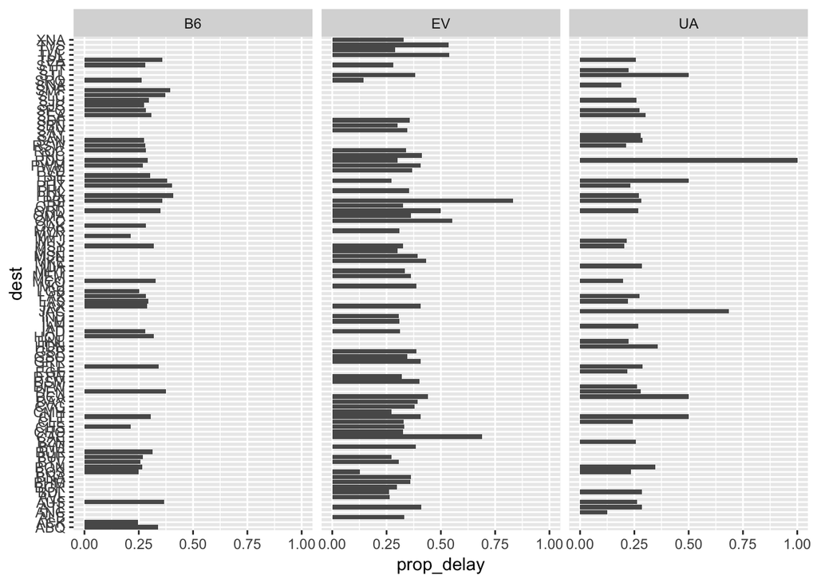

```r
flights %>% filter(carrier %in% c('EV', 'UA', 'B6')) %>%
  mutate(delayed = arr_delay > 10) %>%
  group_by(dest, carrier) %>%
  summarise(prop_delay = mean(delayed, na.rm = TRUE)) %>%
  ggplot(aes(x = dest, y = prop_delay)) +
  geom_bar(stat = 'identity') +
  coord_flip() +
  facet_wrap(~carrier)
```

# destinations with worst delay

```r
#delays arranged by carrier and destination
carriers_worst_delay_carrierdest <- flights %>%

                        group_by(carrier,dest) %>%
                        summarize(count = n(),
                                delay = mean(arr_delay, na.rm = TRUE),
                                proportion_delay = delay/count
                        ) %>%

                       arrange(desc(proportion_delay))


 carriers_worst_delay_carrierdest
```

```
## # A tibble: 314 x 5
## # Groups:   carrier [16]
##    carrier  dest count     delay proportion_delay
##      <chr> <chr> <int>     <dbl>            <dbl>
##  1      OO   ORD     1 107.00000       107.000000
##  2      UA   RDU     1  56.00000        56.000000
##  3      UA   STL     2 110.00000        55.000000
##  4      OO   DTW     2  68.50000        34.250000
##  5      9E   GSO     1  13.00000        13.000000
##  6      9E   MSN     1  12.00000        12.000000
##  7      VX   SJC     1  11.00000        11.000000
##  8      EV   ORD     2  17.50000         8.750000
##  9      UA   CLT     2  14.50000         7.250000
## 10      EV   PBI     6  40.66667         6.777778
## # ... with 304 more rows
```

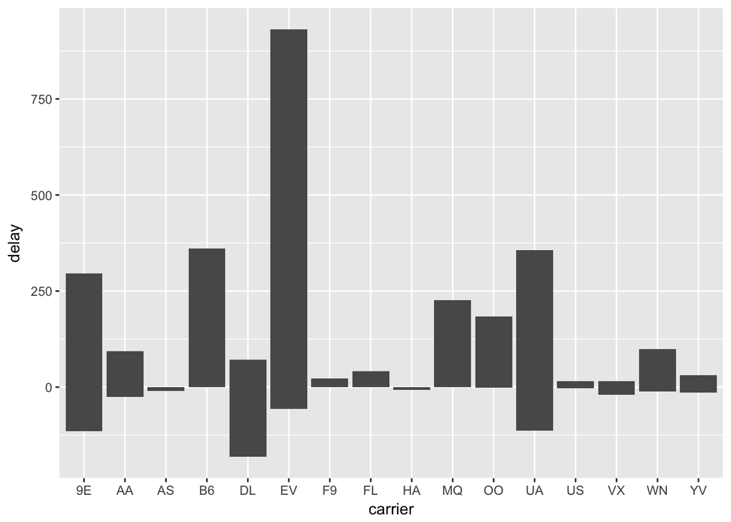

```r
  ggplot(data = carriers_worst_delay_carrierdest, mapping = aes(x = carrier, y = delay)) +
  geom_col()
```

# 6.What does the sort argument to count() do. When might you use it?

# sort argument on count() sorts the results of the count() in descending order.

```r
carriers <- flights %>%
            group_by(carrier) %>%
            count(carrier, sort = TRUE)
carriers
```

```
## # A tibble: 16 x 2
## # Groups:   carrier [16]
##    carrier     n
##      <chr> <int>
##  1      UA 58665
##  2      B6 54635
##  3      EV 54173
##  4      DL 48110
##  5      AA 32729
##  6      MQ 26397
##  7      US 20536
##  8      9E 18460
##  9      WN 12275
## 10      VX  5162
## 11      FL  3260
## 12      AS   714
## 13      F9   685
## 14      YV   601
## 15      HA   342
## 16      OO    32
```

# Section 10.5: #1, #2, #3 and #6 only

# 10.5 Exercises

# 1.How can you tell if an object is a tibble? (Hint: try printing mtcars, which is a regular data frame).

# mtcars is a dataframe. It can be converted to a tibble using as_tibble(mtcars).

# print(mtcars) prints the dataframe. print(as_tibble(mtcars)) prints it in the form of a tibble.

```r
print(mtcars)
```

```
##                      mpg cyl  disp  hp drat    wt  qsec vs am gear carb
## Mazda RX4           21.0   6 160.0 110 3.90 2.620 16.46  0  1    4    4
## Mazda RX4 Wag       21.0   6 160.0 110 3.90 2.875 17.02  0  1    4    4
## Datsun 710          22.8   4 108.0  93 3.85 2.320 18.61  1  1    4    1
## Hornet 4 Drive      21.4   6 258.0 110 3.08 3.215 19.44  1  0    3    1
## Hornet Sportabout   18.7   8 360.0 175 3.15 3.440 17.02  0  0    3    2
## Valiant             18.1   6 225.0 105 2.76 3.460 20.22  1  0    3    1
## Duster 360          14.3   8 360.0 245 3.21 3.570 15.84  0  0    3    4
## Merc 240D           24.4   4 146.7  62 3.69 3.190 20.00  1  0    4    2
## Merc 230            22.8   4 140.8  95 3.92 3.150 22.90  1  0    4    2
## Merc 280            19.2   6 167.6 123 3.92 3.440 18.30  1  0    4    4
## Merc 280C           17.8   6 167.6 123 3.92 3.440 18.90  1  0    4    4
## Merc 450SE          16.4   8 275.8 180 3.07 4.070 17.40  0  0    3    3
## Merc 450SL          17.3   8 275.8 180 3.07 3.730 17.60  0  0    3    3
## Merc 450SLC         15.2   8 275.8 180 3.07 3.780 18.00  0  0    3    3
## Cadillac Fleetwood  10.4   8 472.0 205 2.93 5.250 17.98  0  0    3    4
## Lincoln Continental 10.4   8 460.0 215 3.00 5.424 17.82  0  0    3    4
## Chrysler Imperial   14.7   8 440.0 230 3.23 5.345 17.42  0  0    3    4
## Fiat 128            32.4   4  78.7  66 4.08 2.200 19.47  1  1    4    1
## Honda Civic         30.4   4  75.7  52 4.93 1.615 18.52  1  1    4    2
## Toyota Corolla      33.9   4  71.1  65 4.22 1.835 19.90  1  1    4    1
## Toyota Corona       21.5   4 120.1  97 3.70 2.465 20.01  1  0    3    1
## Dodge Challenger    15.5   8 318.0 150 2.76 3.520 16.87  0  0    3    2
## AMC Javelin         15.2   8 304.0 150 3.15 3.435 17.30  0  0    3    2
## Camaro Z28          13.3   8 350.0 245 3.73 3.840 15.41  0  0    3    4
## Pontiac Firebird    19.2   8 400.0 175 3.08 3.845 17.05  0  0    3    2
## Fiat X1-9           27.3   4  79.0  66 4.08 1.935 18.90  1  1    4    1
## Porsche 914-2       26.0   4 120.3  91 4.43 2.140 16.70  0  1    5    2
## Lotus Europa        30.4   4  95.1 113 3.77 1.513 16.90  1  1    5    2
## Ford Pantera L      15.8   8 351.0 264 4.22 3.170 14.50  0  1    5    4
## Ferrari Dino        19.7   6 145.0 175 3.62 2.770 15.50  0  1    5    6
## Maserati Bora       15.0   8 301.0 335 3.54 3.570 14.60  0  1    5    8
## Volvo 142E          21.4   4 121.0 109 4.11 2.780 18.60  1  1    4    2
```

```r
print(as_tibble(mtcars))
```

```
## # A tibble: 32 x 11
##      mpg   cyl  disp    hp  drat    wt  qsec    vs    am  gear  carb
##  * <dbl> <dbl> <dbl> <dbl> <dbl> <dbl> <dbl> <dbl> <dbl> <dbl> <dbl>
##  1  21.0     6 160.0   110  3.90 2.620 16.46     0     1     4     4
##  2  21.0     6 160.0   110  3.90 2.875 17.02     0     1     4     4
##  3  22.8     4 108.0    93  3.85 2.320 18.61     1     1     4     1
##  4  21.4     6 258.0   110  3.08 3.215 19.44     1     0     3     1
##  5  18.7     8 360.0   175  3.15 3.440 17.02     0     0     3     2
##  6  18.1     6 225.0   105  2.76 3.460 20.22     1     0     3     1
##  7  14.3     8 360.0   245  3.21 3.570 15.84     0     0     3     4
##  8  24.4     4 146.7    62  3.69 3.190 20.00     1     0     4     2
##  9  22.8     4 140.8    95  3.92 3.150 22.90     1     0     4     2
## 10  19.2     6 167.6   123  3.92 3.440 18.30     1     0     4     4
## # ... with 22 more rows
```

# 2.Compare and contrast the following operations on a data.frame and equivalent tibble. What is different? Why might the default data frame behaviours cause you frustration?

# df <- data.frame(abc = 1, xyz = “a”)

# df[, c(“abc”, “xyz”)]

# on a dataframe

```r
df <- data.frame(abc = 1, xyz = "a")
df
```

```
##   abc xyz
## 1   1   a
```

```r
df$x
```

```
## [1] a
## Levels: a
```

```r
df[, "xyz"]
```

```
## [1] a
## Levels: a
```

```r
df[, c("abc", "xyz")]
```

```
##   abc xyz
## 1   1   a
```